# R workshop @TESRI

## 箱形圖 (Boxplot)

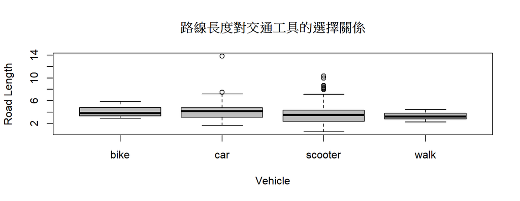

```r
boxplot(formula = `Length (KM)`~Vehicle,  # Y ~ X (代表X和Y軸要放的數值)
        data =  rk2018,  # 資料
#-------版面調整
        main = "路線長度對交通工具的選擇關係",
        xlab = "Vehicle",  # X軸名稱
        ylab = "Road Length",  # Y軸名稱
        col ="gray")  # 設定顏色
```

## 散布圖 (Scatter Plot)

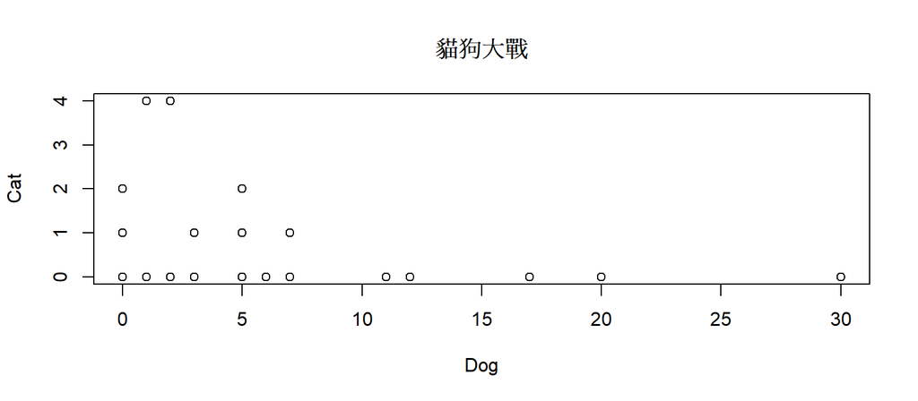

```r
plot(x = rk2018$Doggy,
     y = rk2018$Kitty,
     main = "貓狗大戰",  # 圖片的名稱
     xlab = "Dog",  # X軸的名稱
     ylab = "Cat")  # y軸的名稱
```

## 進階繪圖：ggplot

### {ggplot2} 是以繪圖文法概念為基礎所發展出來的一套 R 繪圖套件

- 可依照需求組合各種圖形組件
- 任意調整圖形，具有彈性

## ggplot 繪圖結構

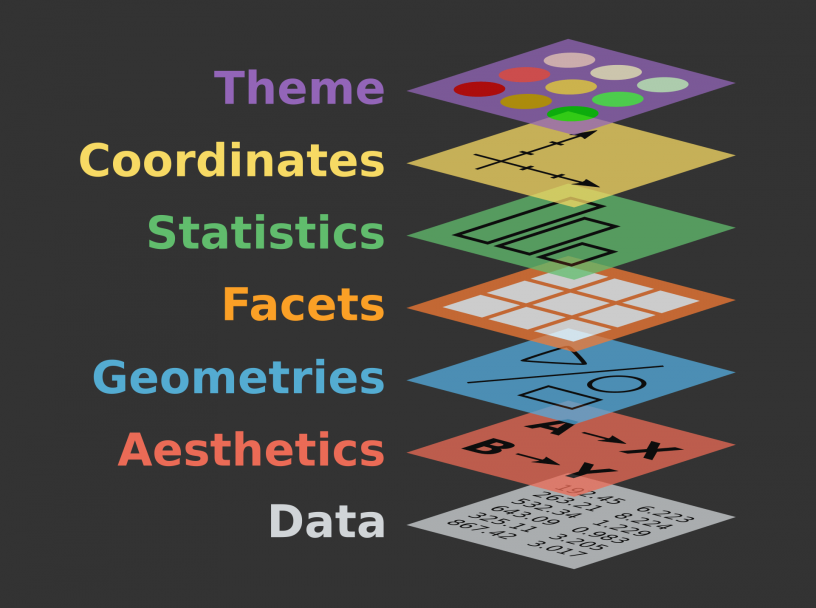

- **Data（資料來源）**：指定原始資料來源的 data frame
- **Aesthetic（美學對應）**：指定原始資料與圖形之間的對應關係， ie: x & y座標變數，資料繪圖時的樣式等
- **Geometry（幾何圖案）**：要用什麼幾何圖形繪製資料，ie: 點、線條、多邊形
- **Facet（繪圖面）**：指定如何將資料分散在多張子圖形中繪製，常用於比較圖表
- **Statistical transformation（統計轉換）**：指定如何以將資料轉換為各種統計量，ex: 將連續型資料轉為離散型類別
- **Coordinate system（座標系統）**：指定繪圖時所使用的座標系統
- **Theme（主題）**：控制資料以外的繪圖組件，ie: 座標軸、說明文字

## ggplot 繪圖文法

**Plot = Data + Aesthetics + Geometry**

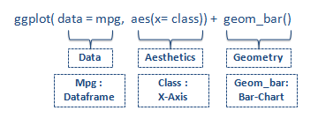

```r
library(ggplot2) # load package
```

## {graphics} vs. {ggplot2} : 散布圖

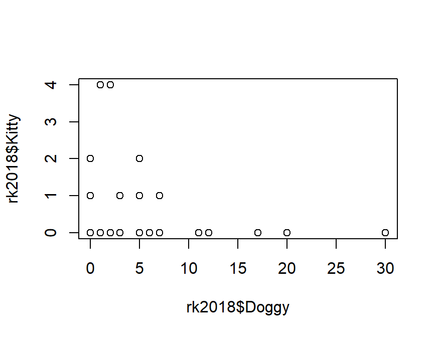

```r
 plot(x = rk2018$Doggy, y = rk2018$Kitty)
```

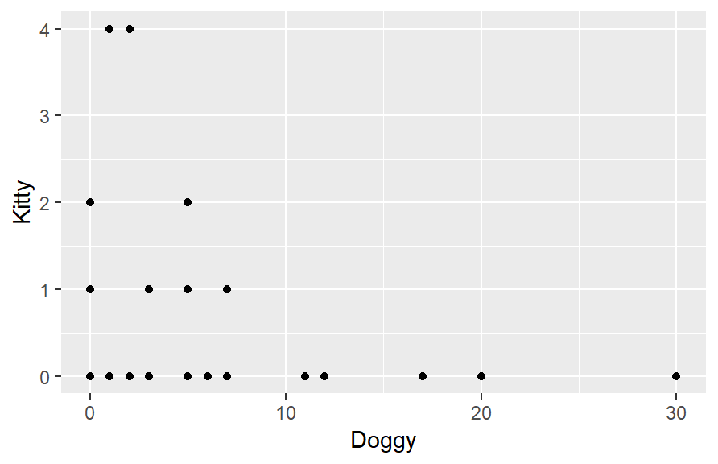

```r
ggplot(data =  rk2018,
       aes(x = Doggy, y = Kitty)) +
  geom_point()
```

## ggplot 基本圖表繪製

- `hist()`
- `barplot`
- `boxplot()`
- `plot()`
- `+geom_histogram()`
- `+geom_bar()`
- `+geom_boxplot()`
- `+geom_point()`

Try it!

## 比較不同類別差異

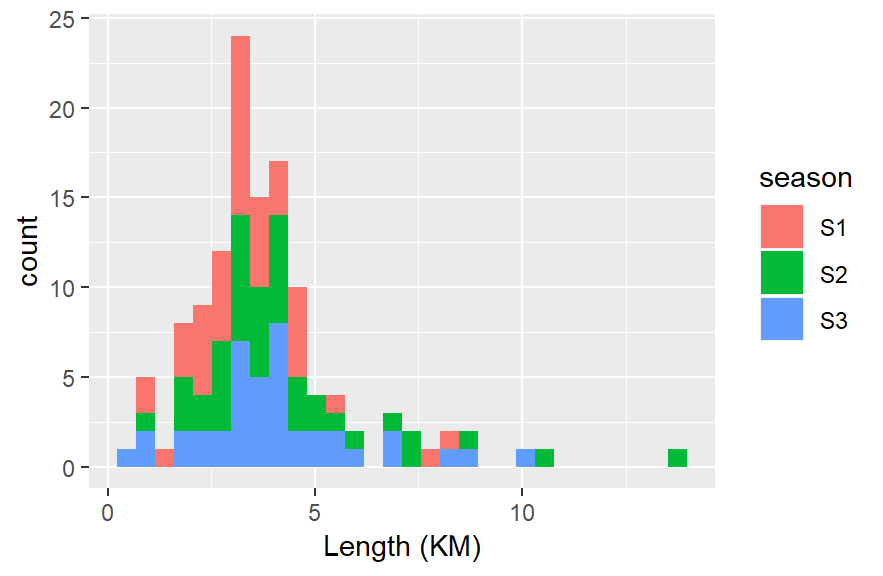

```r
#### 利用 fill 區分類別
  ggplot(data =  rk2018) +
    geom_histogram(aes(`Length (KM)`,
                       bins = 30,
                       fill = season))
```

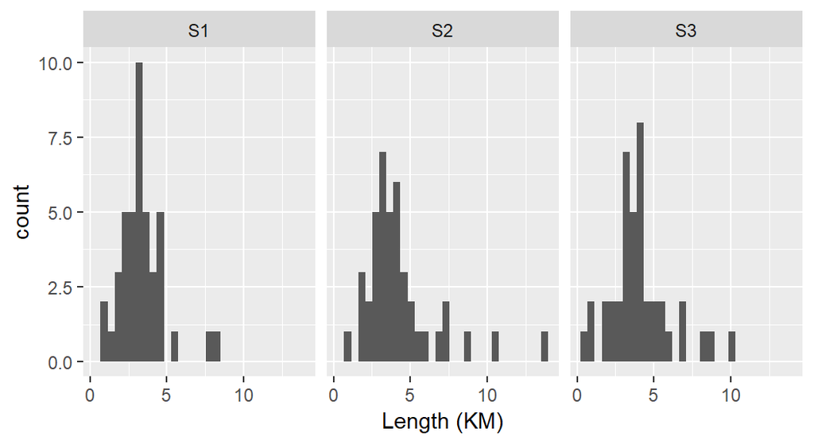

```r
#### 利用 facet_grid/facet_wrap 比較不同類別差異
  ggplot(data =  rk2018) +
    geom_histogram(aes(`Length (KM)`),
                   bins = 30) +
    facet_grid(.~season)
```

## ggplot 常用設定

**`labs()` 標題內容**

- title: 標題
- subtitle: 副標題
- caption: 說明文字
- x: X軸名稱
- y: Y軸名稱
- fill/colour: 圖例名

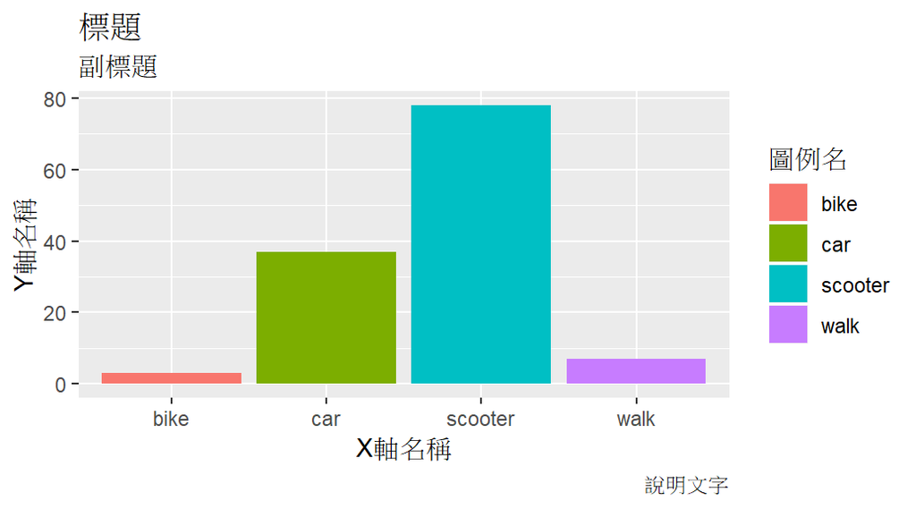

```r
ggplot(data =  rk2018,
       aes(x = Vehicle, fill = Vehicle)) +
  geom_bar() +
  labs(title = "標題", subtitle = "副標題",
       caption = "說明文字",
       x = "X軸名稱", y = "Y軸名稱",
       fill = "圖例名")
```

## ggplot 常用版面設定

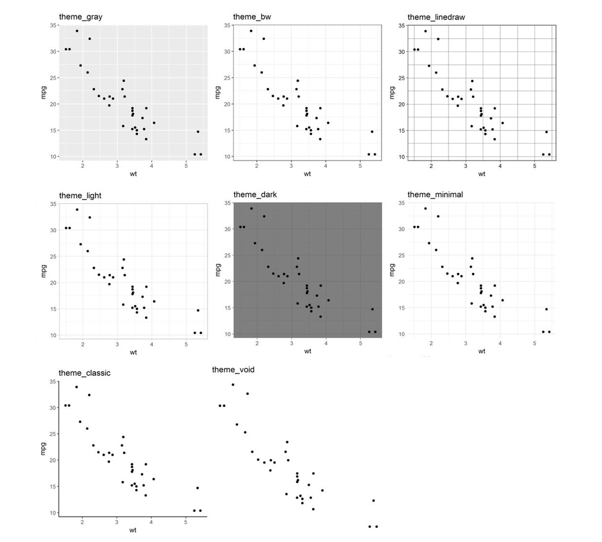

**ggplot2 內建主題**  
`theme_gray()` # 預設  
`theme_bw()`  
`theme_linedraw()`  
`theme_light()`  
`theme_dark()`  
`theme_minimal()`  
`theme_classic()`  
`theme_void()`

## 畫出像 BBC 一樣的圖： {bbplot} package

**Create data visualizations like BBC News with the BBC’s R Cookbook** [(https://reurl.cc/vkxka)](https://reurl.cc/vkxka)

[figure not shown]

## 輸出圖表

`ggsave()`

```r
ggsave(filename, plot = last_plot(),
#------以下可有可無
       path = NULL,
       width = NA, height = NA,
       units = c("in", "cm", "mm"), dpi = 300)
```

- filename: 須包含副檔名
- 可接受： "png", "jpeg", "eps", "ps", "tex" (pictex), "pdf", "tiff", "bmp", "svg" or "wmf" (windows only)

## Reference

- [資料視覺化Data Visualization：圖表設計](https://medium.com/uxeastmeetswest/%E8%B3%87%E6%96%99%E8%A6%96%E8%A6%BA%E5%8C%96data-visualization-%E5%9C%96%E8%A1%A8%E8%A8%AD%E8%A8%88-9ef17943a2d4) (Medium uxeastmeetswest)
- [R筆記–(4)繪圖-資料視覺化](https://rpubs.com/skydome20/R-Note4-Plotting_System)
- [淺談資料視覺化以及 ggplot2 實踐](https://leemeng.tw/data-visualization-from-matplotlib-to-ggplot2.html)
- [R ggplot2 教學：基本概念與 qplot 函數](https://blog.gtwang.org/r/ggplot2-tutorial-basic-concept-and-qplot/)
- [Top 10 Classical Errors in data Visualization](https://ecmapping.com/2017/10/25/top-10-classical-errors-in-data-visualization/?fbclid=IwAR2pjC5QXImjt9SonTR4dn2yeCNy0YioRG753ROxtYglFDWX32R14qphpl0)